# Association Not Causation

2022-11-13

## Association is not causation

- *Association is not causation* is perhaps the most important lesson one learns in a statistics class.
- *Correlation is not causation* is another way to say this.
- Throughout the Statistics part of the book, we have described tools useful for quantifying associations between variables.
- However, we must be careful not to over-interpret these associations.
- There are many reasons that a variable \(X\) can be correlated with a variable \(Y\) without having any direct effect on \(Y\).
- Here we examine four common ways that can lead to misinterpreting data.

## Spurious correlation

- The following comical example underscores that correlation is not causation.
- It shows a very strong correlation between divorce rates and margarine consumption.

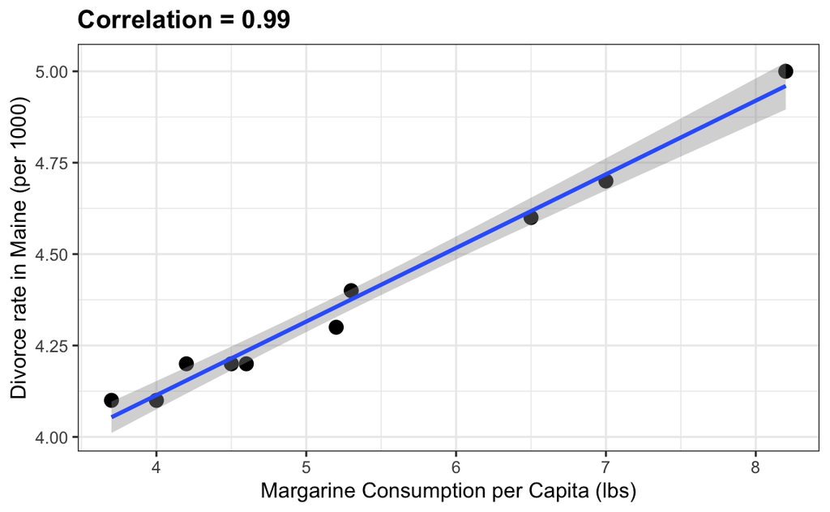

## Spurious correlation

- Does this mean that margarine causes divorces? Or do divorces cause people to eat more margarine? Of course the answer to both these questions is no.
- This is just an example of what we call a *spurious correlation*.
- You can see many more absurd examples on the Spurious [Correlations website](http://tylervigen.com/spurious-correlations).
- The cases presented in the spurious correlation site are all instances of what is generally called *data dredging*, *data fishing*, or *data snooping*.

## Spurious correlation

- It’s basically a form of what in the US they call *cherry picking*.
- An example of data dredging would be if you look through many results produced by a random process and pick the one that shows a relationship that supports a theory you want to defend.
- A Monte Carlo simulation can be used to show how data dredging can result in finding high correlations among uncorrelated variables.
- We will save the results of our simulation into a tibble:

## Spurious correlation

```r
N <- 25
g <- 1000000
sim_data <- tibble(group = rep(1:g, each=N),
                   x = rnorm(N * g),
                   y = rnorm(N * g))
```

- The first column denotes group.
- We created groups and for each one we generated a pair of independent vectors, \(X\) and \(Y\), with 25 observations each, stored in the second and third columns.
- Because we constructed the simulation, we know that \(X\) and \(Y\) are not correlated.

## Spurious correlation

- Next, we compute the correlation between `X` and `Y` for each group and look at the max:

```r
res <- sim_data |>  group_by(group) |>
  summarize(r = cor(x, y)) |>  arrange(desc(r))
res |> head(4)
```

```
#> # A tibble: 4 × 2
#>    group     r
#>    <int> <dbl>
#> 1 380863 0.784
#> 2 748428 0.780
#> 3 128479 0.763
#> 4 967137 0.757
```

## Spurious correlation

- We see a maximum correlation of 0.784 and if you just plot the data from the group achieving this correlation, it shows a convincing plot that \(X\) and \(Y\) are in fact correlated:

```r
sim_data |> filter(group == res$group[which.max(res$r)]) |>
  ggplot(aes(x, y)) +
  geom_point() +
  geom_smooth(method = "lm", formula = "y~x")
```

## Spurious correlation

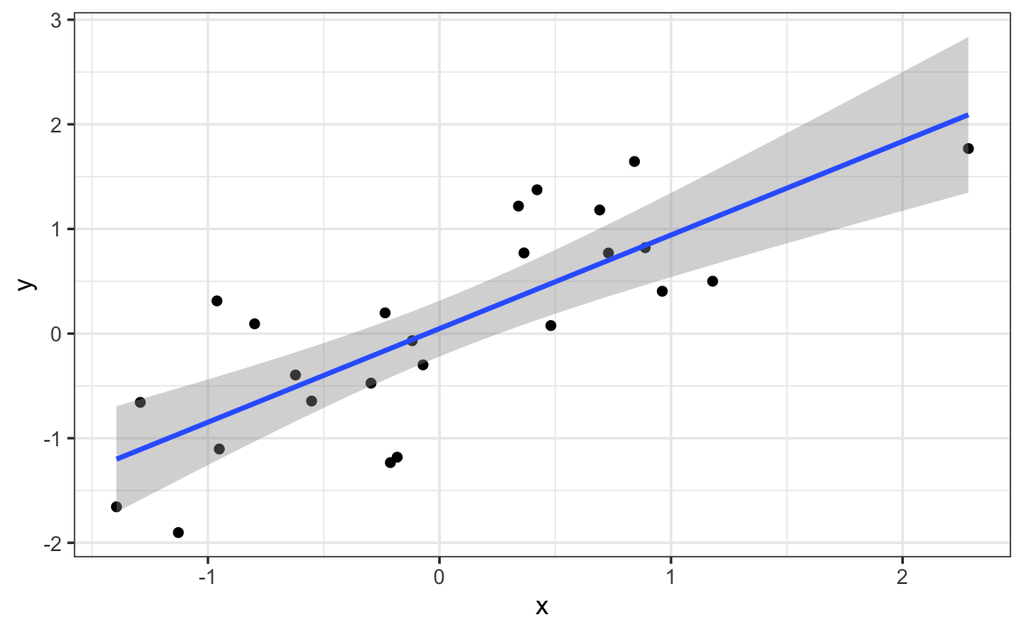

## Spurious correlation

- Remember that the correlation summary is a random variable.
- Here is the distribution generated by the Monte Carlo simulation:

```r
res |> ggplot(aes(x=r)) +
  geom_histogram(binwidth = 0.1, color = "black")
```

## Spurious correlation

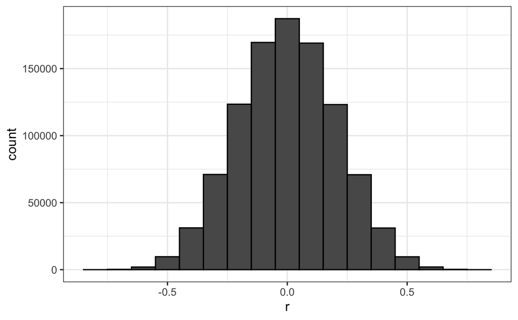

## Spurious correlation

- It’s just a mathematical fact that if we observe random correlations that are expected to be 0, but have a standard error of 0.204, the largest one will be close to 1.
- If we performed regression on this group and interpreted the p-value, we would incorrectly claim this was a statistically significant relation:

```r
library(broom)
sim_data |>
  filter(group == res$group[which.max(res$r)]) |>
  summarize(tidy(lm(y ~ x))) |>
  filter(term == "x")
```

```
#> # A tibble: 1 × 5
#>   term  estimate std.error statistic    p.value
#>   <chr>    <dbl>     <dbl>     <dbl>      <dbl>
#> 1 x        0.895     0.148      6.05 0.00000362
```

## Spurious correlation

- This particular form of data dredging is referred to as *p-hacking*.
- P-hacking is a topic of much discussion because it is a problem in scientific publications.
- Because publishers tend to reward statistically significant results over negative results, there is an incentive to report significant results.
- In epidemiology and the social sciences, for example, researchers may look for associations between an adverse outcome and several exposures and report only the one exposure that resulted in a small p-value.

## Spurious correlation

- Furthermore, they might try fitting several different models to account for confounding and pick the one that yields the smallest p-value.
- In experimental disciplines, an experiment might be repeated more than once, yet only the results of the one experiment with a small p-value reported.
- This does not necessarily happen due to unethical behavior, but rather as a result of statistical ignorance or wishful thinking.
- In advanced statistics courses, you can learn methods to adjust for these multiple comparisons.

## Outliers

- Suppose we take measurements from two independent outcomes, \(X\) and \(Y\), and we standardize the measurements.
- However, imagine we make a mistake and forget to standardize entry 23.
- We can simulate such data using:

```r
set.seed(1985)
x <- rnorm(100,100,1)
y <- rnorm(100,84,1)
x[-23] <- scale(x[-23])
y[-23] <- scale(y[-23])
```

## Outliers

- The data look like this:

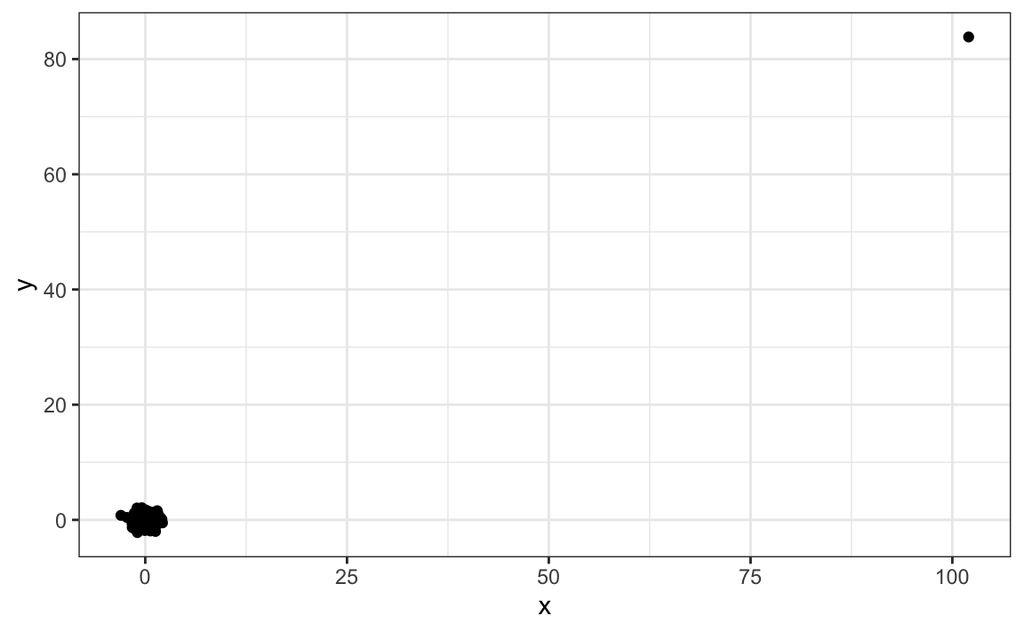

```r
qplot(x, y)
```

## Outliers

- Not surprisingly, the correlation is very high:

```r
cor(x,y)
```

```
#> [1] 0.988
```

- But this is driven by the one outlier.

## Outliers

- If we remove this outlier, the correlation is greatly reduced to almost 0, which is what it should be:

```r
cor(x[-23], y[-23])
```

```
#> [1] -0.0442
```

- There is an alternative to the sample correlation for estimating the population correlation that is robust to outliers.
- It is called *Spearman correlation*.

## Outliers

- The idea is simple: compute the correlation on the ranks of the values.
- Here is a plot of the ranks plotted against each other:

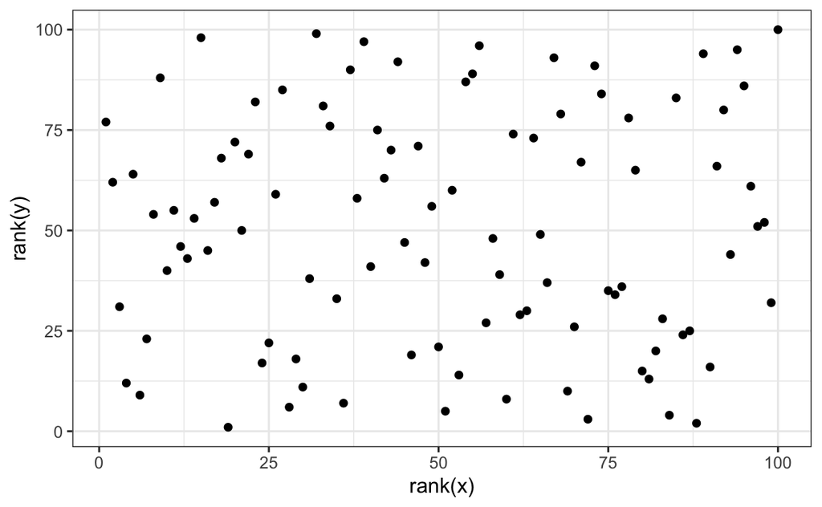

```r
qplot(rank(x), rank(y))
```

## Outliers

- The outlier is no longer associated with a very large value and the correlation comes way down:

```r
cor(rank(x), rank(y))
```

```
#> [1] 0.00251
```

- Spearman correlation can also be calculated like this:

```r
cor(x, y, method = "spearman")
```

```
#> [1] 0.00251
```

- There are also methods for robust fitting of linear models which you can learn about in, for instance, this book: Robust Statistics: Edition 2 by Peter J. Huber & Elvezio M. Ronchetti.

## Reversing cause and effect

- Another way association is confused with causation is when the cause and effect are reversed.
- An example of this is claiming that tutoring makes students perform worse because they test lower than peers that are not tutored.
- In this case, the tutoring is not causing the low test scores, but the other way around.
- A form of this claim actually made it into an op-ed in the New York Times titled Parental Involvement Is Overrated<sup>1</sup>.

## Reversing cause and effect

- Consider this quote from the article:

> > When we examined whether regular help with homework had a positive impact on children’s academic performance, we were quite startled by what we found. Regardless of a family’s social class, racial or ethnic background, or a child’s grade level, consistent homework help almost never improved test scores or grades… Even more surprising to us was that when parents regularly helped with homework, kids usually performed worse.
- A very likely possibility is that the children needing regular parental help, receive this help because they don’t perform well in school.

## Reversing cause and effect

- We can easily construct an example of cause and effect reversal using the father and son height data.
- If we fit the model:

\[X_i = \beta_0 + \beta_1 y_i + \varepsilon_i, i=1, \dots, N\]

- to the father and son height data, with \(X_i\) the father height and \(y_i\) the son height, we do get a statistically significant result.

## Reversing cause and effect

- We use the `galton_heights` dataset previously shown

```r
galton_heights |> summarize(tidy(lm(father ~ son)))
```

```
#> # A tibble: 2 × 5
#>   term        estimate std.error statistic  p.value
#>   <chr>          <dbl>     <dbl>     <dbl>    <dbl>
#> 1 (Intercept)   40.9      4.40        9.29 5.47e-17
#> 2 son            0.407    0.0636      6.40 1.36e- 9
```

- The model fits the data very well.

## Reversing cause and effect

- If we look at the mathematical formulation of the model above, it could easily be incorrectly interpreted so as to suggest that the son being tall caused the father to be tall.
- But given what we know about genetics and biology, we know it’s the other way around.
- The model is technically correct.
- The estimates and p-values were obtained correctly as well.
- What is wrong here is the interpretation.

## Confounders

- Confounders are perhaps the most common reason that leads to associations begin misinterpreted.
- If \(X\) and \(Y\) are correlated, we call \(Z\) a *confounder* if changes in \(Z\) causes changes in both \(X\) and \(Y\).
- Earlier, when studying baseball data, we saw how Home Runs was a confounder that resulted in a higher correlation than expected when studying the relationship between Bases on Balls and Runs.
- In some cases, we can use linear models to account for confounders.

## Confounders

- However, this is not always the case.
- Incorrect interpretation due to confounders is ubiquitous in the lay press and they are often hard to detect.
- Here, we present a widely used example related to college admissions.

## Example: UC Berkeley admissions

- Admission data from six U.C.
- Berkeley majors, from 1973, showed that more men were being admitted than women: 44% men were admitted compared to 30% women.
- PJ Bickel, EA Hammel, and JW O’Connell. Science (1975).

## Example: UC Berkeley admissions

- We can load the data and run

```r
data(admissions)
admissions |> group_by(gender) |>
  summarize(percentage =
              round(sum(admitted*applicants)/sum(applicants),1))
```

```
#> # A tibble: 2 × 2
#>   gender percentage
#>   <chr>       <dbl>
#> 1 men          44.5
#> 2 women        30.3
```

- a statistical test, which clearly rejects the hypothesis that gender and admission are independent:

## Example: UC Berkeley admissions

```r
data(admissions)
two_by_two <- admissions |> group_by(gender) |>
  summarize(total_admitted = round(sum(admitted / 100 * applicants)),
            not_admitted = sum(applicants) - sum(total_admitted)) |>
  select(-gender)
chisq.test(two_by_two)$p.value
```

```
#> [1] 1.06e-21
```

- But closer inspection shows a paradoxical result.

## Example: UC Berkeley admissions

- Here are the percent admissions by major:

```r
admissions |> select(major, gender, admitted) |>
  pivot_wider(names_from = "gender", values_from = "admitted") |>
  mutate(women_minus_men = women - men)
```

```
#> # A tibble: 6 × 4
#>   major   men women women_minus_men
#>   <chr> <dbl> <dbl>           <dbl>
#> 1 A        62    82              20
#> 2 B        63    68               5
#> 3 C        37    34              -3
#> 4 D        33    35               2
#> 5 E        28    24              -4
#> 6 F         6     7               1
```

- Four out of the six majors favor women.

## Example: UC Berkeley admissions

- More importantly, all the differences are much smaller than the 14.2 difference that we see when examining the totals.
- The paradox is that analyzing the totals suggests a dependence between admission and gender, but when the data is grouped by major, this dependence seems to disappear.
- What’s going on? This actually can happen if an uncounted confounder is driving most of the variability.

## Example: UC Berkeley admissions

- So let’s define three variables: \(X\) is 1 for men and 0 for women, \(Y\) is 1 for those admitted and 0 otherwise, and \(Z\) quantifies the selectivity of the major.
- A gender bias claim would be based on the fact that \(\mbox{Pr}(Y=1 | X = x)\) is higher for \(x=1\) than \(x=0\).
- However, \(Z\) is an important confounder to consider.
- Clearly \(Z\) is associated with \(Y\), as the more selective a major, the lower \(\mbox{Pr}(Y=1 | Z = z)\).
- But is major selectivity \(Z\) associated with gender \(X\)?

## Example: UC Berkeley admissions

- One way to see this is to plot the total percent admitted to a major versus the percent of women that made up the applicants:

```r
admissions |>
  group_by(major) |>
  summarize(major_selectivity = sum(admitted * applicants)/sum(applicants),
            percent_women_applicants = sum(applicants * (gender=="women")) /
                                             sum(applicants) * 100) |>
  ggplot(aes(major_selectivity, percent_women_applicants, label = major)) +
  geom_text()
```

## Example: UC Berkeley admissions

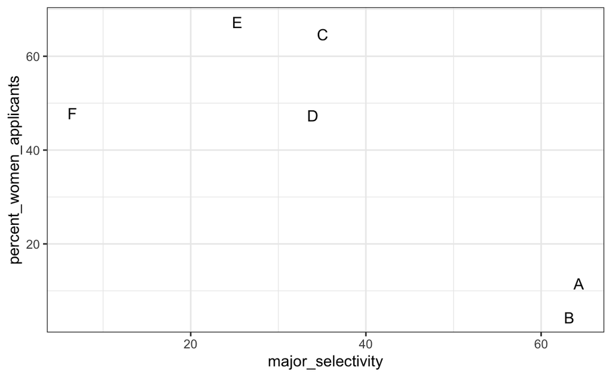

- There seems to be association.

## Example: UC Berkeley admissions

- The plot suggests that women were much more likely to apply to the two “hard” majors: gender and major’s selectivity are confounded.
- Compare, for example, major B and major E.
- Major E is much harder to enter than major B and over 60% of applicants to major E were women, while less than 30% of the applicants of major B were women.

## Confounding explained graphically

- The following plots shows the number of applicants that were admitted and those that were not and breaks down the acceptances by major.

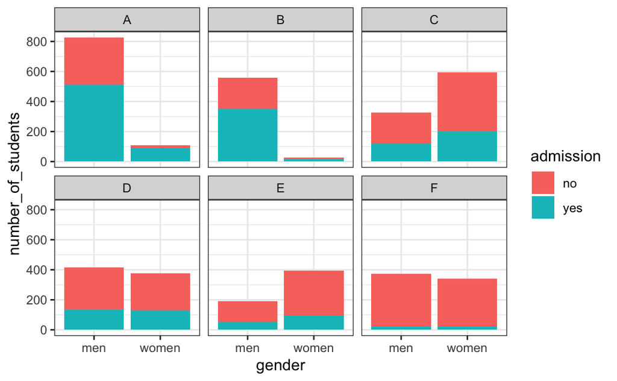

## Confounding explained graphically

```r
admissions |>
  mutate(percent_admitted = admitted * applicants/sum(applicants)) |>
  ggplot(aes(gender, y = percent_admitted, fill = major)) +
  geom_bar(stat = "identity", position = "stack")
```

## Confounding explained graphically

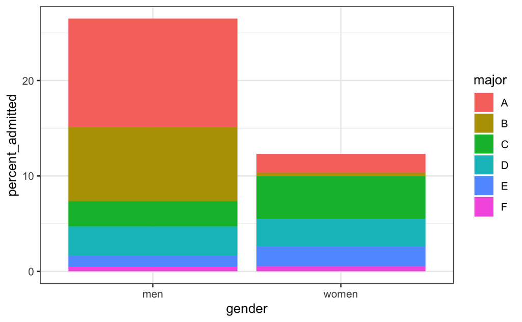

## Confounding explained graphically

- This breakdown allows us to see that the majority of accepted men came from two majors: A and B.
- It also lets us see that few women applied to these majors.

## Average after stratifying

- In this plot, we can see that if we condition or stratify by major, and then look at differences, we control for the confounder and this effect goes away:

```r
admissions |>
  ggplot(aes(major, admitted, col = gender, size = applicants)) +
  geom_point()
```

## Average after stratifying

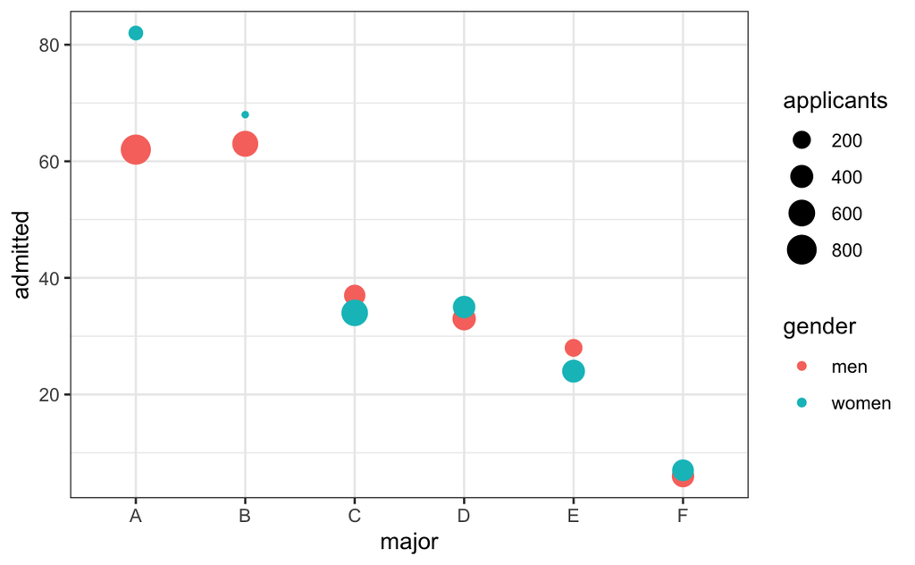

## Average after stratifying

- Now we see that major by major, there is not much difference.
- The size of the dot represents the number of applicants, and explains the paradox: we see large red dots and small blue dots for the easiest majors, A and B.
- If we average the difference by major, we find that the percent is actually 3.5% higher for women.

```r
admissions |>  group_by(gender) |> summarize(average = mean(admitted))
```

```
#> # A tibble: 2 × 2
#>   gender average
#>   <chr>    <dbl>
#> 1 men       38.2
#> 2 women     41.7
```

## Simpson’s paradox

- The case we have just covered is an example of Simpson’s paradox.
- It is called a paradox because we see the sign of the correlation flip when comparing the entire publication and specific strata.
- As an illustrative example, suppose you have three random variables \(X\), \(Y\), and \(Z\) and that we observe realizations of these.
- Here is a plot of simulated observations for \(X\) and \(Y\) along with the sample correlation:

## Simpson’s paradox

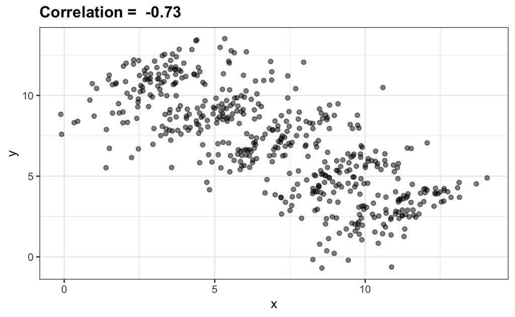

## Simpson’s paradox

- You can see that \(X\) and \(Y\) are negatively correlated.
- However, once we stratify by \(Z\) (shown in different colors below) another pattern emerges:

## Simpson’s paradox

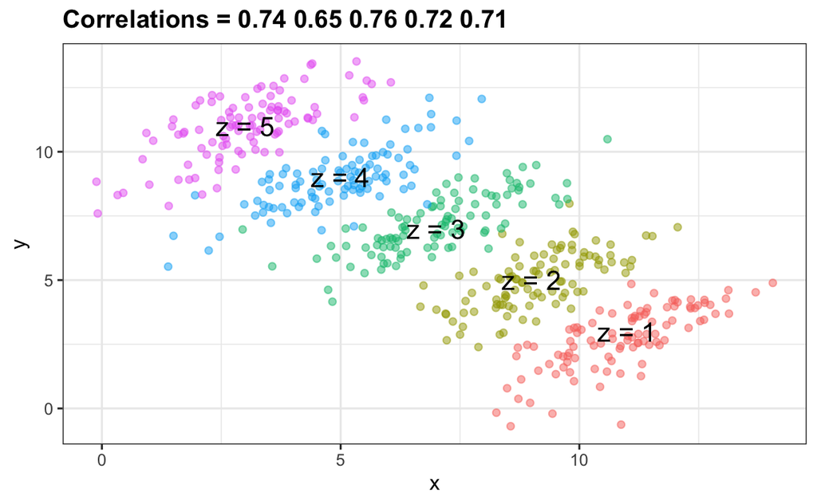

## Simpson’s paradox

- It is really \(Z\) that is negatively correlated with \(X\).
- If we stratify by \(Z\), the \(X\) and \(Y\) are actually positively correlated as seen in the plot above.